# Construct 1 and 2 meta-analysis

# Power of studies included in the analysis

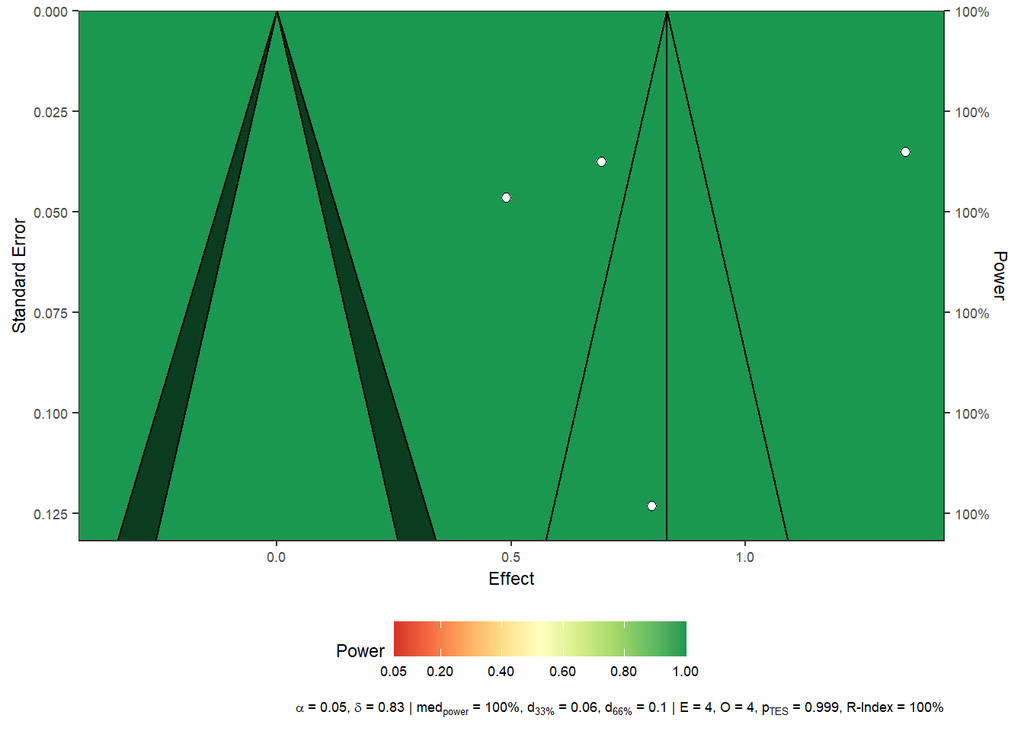

# Mean reliability scale (for supplementary)

| Variable | Artifact | Artifact_Description | k_total | N_total | mean | sd | sd_res |
| --- | --- | --- | --- | --- | --- | --- | --- |
| Construct1.1 | qxi_irr | Restricted reliability index (indirect RR) | 4 | 2 073 | .631 | .270 | .269 |
| Construct1.1 | rxxi_irr | Restricted reliability coefficient (indirect RR) | 4 | 2 073 | .453 | .312 | .311 |
| Construct1.2 | qxi_irr | Restricted reliability index (indirect RR) | 4 | 2 659 | .630 | .203 | .201 |
| Construct1.2 | rxxi_irr | Restricted reliability coefficient (indirect RR) | 4 | 2 659 | .427 | .199 | .197 |
| Construct1.3 | qxi_irr | Restricted reliability index (indirect RR) | 4 | 1 818 | .562 | .308 | .307 |
| Construct1.3 | rxxi_irr | Restricted reliability coefficient (indirect RR) | 4 | 1 818 | .387 | .388 | .386 |
| Construct2.1 | qxi_irr | Restricted reliability index (indirect RR) | 4 | 1 907 | .778 | .104 | .103 |
| Construct2.1 | rxxi_irr | Restricted reliability coefficient (indirect RR) | 4 | 1 907 | .613 | .169 | .166 |
| Construct2.2 | qxi_irr | Restricted reliability index (indirect RR) | 4 | 2 429 | .795 | .293 | .293 |
| Construct2.2 | rxxi_irr | Restricted reliability coefficient (indirect RR) | 4 | 2 429 | .697 | .356 | .356 |
| Construct2.3 | qxi_irr | Restricted reliability index (indirect RR) | 4 | 2 214 | .729 | .183 | .182 |
| Construct2.3 | rxxi_irr | Restricted reliability coefficient (indirect RR) | 4 | 2 214 | .556 | .239 | .238 |